# Indicator Discovery Lab

Отдельный исследовательский стенд для ответа на один вопрос: **какие causal-индикаторы, сочетания и компактные модели действительно переносятся на следующий временной блок для разных targets, валют и горизонтов?**

Здесь нет meta-model и клиентской policy. Параметры каждого правила выбираются на rolling train, после чего фиксируются на следующем полугодовом OOS-fold. Все итоговые метрики объединяют только OOS-предсказания. Период после `discovery_end` зарезервирован и не участвует ни в выборе, ни в таблицах.

```python
from datetime import date
from pathlib import Path
import sys

import matplotlib.pyplot as plt
import numpy as np
import pandas as pd

candidate_roots = [Path.cwd(), *Path.cwd().parents]
PROJECT_ROOT = next((
    path.resolve() for path in candidate_roots
    if (path / 'src' / 'cbr_loader.py').is_file()
), None)
if PROJECT_ROOT is None:
    raise RuntimeError('Не найден корень prod с папкой src')
project_root_str = str(PROJECT_ROOT)
sys.path = [item for item in sys.path if item != project_root_str]
sys.path.insert(0, project_root_str)
cached_src = sys.modules.get('src')
expected_src = (PROJECT_ROOT / 'src').resolve()
if cached_src is not None:
    cached_file = Path(getattr(cached_src, '__file__', '') or '.').resolve()
    if expected_src not in cached_file.parents:
        for module_name in [name for name in tuple(sys.modules) if name == 'src' or name.startswith('src.')]:
            del sys.modules[module_name]

from src.cbr_loader import CURRENCIES, load_cbr_history
from src.features import build_features
from src.market_data import build_daily_market_panel
from src.outcomes import add_future_outcomes
from research.yura.src.advanced_indicators import (
    ADVANCED_FEATURES, add_advanced_indicator_features,
    discovery_indicator_rules,
)
from research.yura.src.config import YuraPipelineConfig
from research.yura.src.discovery_targets import build_discovery_targets
from research.yura.src.indicator_discovery import (
    IndicatorDiscoveryConfig, build_discovery_temporal_plan,
    run_rule_indicator_discovery,
    summarize_discovery_folds,
)
from research.yura.src.model_indicator_discovery import (
    MODEL_INDICATOR_SPECS, run_model_indicator_discovery,
)

START_DATE = date(2018, 1, 1)
END_DATE = date.today()
RAW_DIR = PROJECT_ROOT / 'data' / 'raw' / 'cbr'
CURRENCIES_TO_TEST = YuraPipelineConfig().currencies
HORIZONS = YuraPipelineConfig().horizons
DISCOVERY_CONFIG = IndicatorDiscoveryConfig(
    train_months=36, test_months=6, discovery_oos_months=48,
    min_train_signals_per_week=0.25, max_train_signals_per_week=4.0,
    top_rules_per_family=2, max_pair_families=12,
    precision_prior_strength=20.0, min_oos_signals=20,
)
# Полный набор сравнивает линейную модель, HGB до/после advanced features
# и Extra Trees. Для короткого smoke-run можно оставить ('hgb_core', 'hgb_all').
MODEL_SPECS = MODEL_INDICATOR_SPECS
DISCOVERY_CONFIG
```

```
IndicatorDiscoveryConfig(train_months=36, test_months=6, discovery_oos_months=48, min_train_signals_per_week=0.25, max_train_signals_per_week=4.0, top_rules_per_family=2, max_pair_families=12, precision_prior_strength=20.0, min_oos_signals=20)
```

## 1. Данные, causal features и пять target-концепций

Четыре старые концепции — `G0`, `G1`, `W0`, `W1_LEGACY`; пятая — новый `W1_YURA`. У `G1` остаются три заранее заданных tolerance-варианта: это разные определения одного target-концепта, и результаты показываются отдельно.

```python
cbr_history = load_cbr_history(
    start_date=START_DATE, end_date=END_DATE, currencies=CURRENCIES, raw_dir=RAW_DIR,
)
rates = (
    cbr_history.pivot(index='available_at', columns='currency', values='normalized_rate')
    .reindex(columns=list(CURRENCIES)).sort_index()
)
rates.columns.name = None
market_panel = build_daily_market_panel(rates)
features = build_features(market_panel)
features = add_advanced_indicator_features(features)
outcomes = add_future_outcomes(features, horizons=HORIZONS)
dataset, discovery_target_registry = build_discovery_targets(
    outcomes, horizons=HORIZONS, yura_w1_forward_bps=20.0,
)
discovery_data = dataset.loc[
    dataset['is_update_day'] & dataset['currency'].isin(CURRENCIES_TO_TEST)
].copy()
discovery_temporal_plan = build_discovery_temporal_plan(
    discovery_data, DISCOVERY_CONFIG
)
DISCOVERY_END = pd.Timestamp(discovery_temporal_plan.discovery_end.iloc[0])

display(discovery_temporal_plan)
display(discovery_target_registry[[
    'family', 'name', 'scenario', 'horizon', 'description'
]])
pd.DataFrame({
    'first_available_at': [discovery_data['available_at'].min()],
    'last_available_at': [discovery_data['available_at'].max()],
    'rows': [len(discovery_data)],
    'advanced_features': [len(ADVANCED_FEATURES)],
})
```

|  | fold_id | train_start | test_start | test_end | discovery_end | reserved_after |
| --- | --- | --- | --- | --- | --- | --- |
| 0 | 1 | 2018-01-01 | 2021-01-01 | 2021-07-01 | 2025-01-01 | 2025-01-01 |
| 1 | 2 | 2018-07-01 | 2021-07-01 | 2022-01-01 | 2025-01-01 | 2025-01-01 |
| 2 | 3 | 2019-01-01 | 2022-01-01 | 2022-07-01 | 2025-01-01 | 2025-01-01 |
| 3 | 4 | 2019-07-01 | 2022-07-01 | 2023-01-01 | 2025-01-01 | 2025-01-01 |
| 4 | 5 | 2020-01-01 | 2023-01-01 | 2023-07-01 | 2025-01-01 | 2025-01-01 |
| 5 | 6 | 2020-07-01 | 2023-07-01 | 2024-01-01 | 2025-01-01 | 2025-01-01 |
| 6 | 7 | 2021-01-01 | 2024-01-01 | 2024-07-01 | 2025-01-01 | 2025-01-01 |
| 7 | 8 | 2021-07-01 | 2024-07-01 | 2025-01-01 | 2025-01-01 | 2025-01-01 |

|  | family | name | scenario | horizon | description |
| --- | --- | --- | --- | --- | --- |
| 0 | G0 | target_g0_exact_min_h1d | GOOD_NOW | 1 | Exact local minimum in ±h calendar days |
| 1 | G0 | target_g0_exact_min_h3d | GOOD_NOW | 3 | Exact local minimum in ±h calendar days |
| 2 | G0 | target_g0_exact_min_h5d | GOOD_NOW | 5 | Exact local minimum in ±h calendar days |
| 3 | G0 | target_g0_exact_min_h10d | GOOD_NOW | 10 | Exact local minimum in ±h calendar days |
| 4 | G0 | target_g0_exact_min_h20d | GOOD_NOW | 20 | Exact local minimum in ±h calendar days |
| 5 | G1 | target_g1_regret_le_100bps_h1d | GOOD_NOW | 1 | Future regret is not above tolerance |
| 6 | G1 | target_g1_regret_le_25bps_h1d | GOOD_NOW | 1 | Future regret is not above tolerance |
| 7 | G1 | target_g1_regret_le_50bps_h1d | GOOD_NOW | 1 | Future regret is not above tolerance |
| 8 | G1 | target_g1_regret_le_100bps_h3d | GOOD_NOW | 3 | Future regret is not above tolerance |
| 9 | G1 | target_g1_regret_le_25bps_h3d | GOOD_NOW | 3 | Future regret is not above tolerance |
| 10 | G1 | target_g1_regret_le_50bps_h3d | GOOD_NOW | 3 | Future regret is not above tolerance |
| 11 | G1 | target_g1_regret_le_100bps_h5d | GOOD_NOW | 5 | Future regret is not above tolerance |
| 12 | G1 | target_g1_regret_le_25bps_h5d | GOOD_NOW | 5 | Future regret is not above tolerance |
| 13 | G1 | target_g1_regret_le_50bps_h5d | GOOD_NOW | 5 | Future regret is not above tolerance |
| 14 | G1 | target_g1_regret_le_100bps_h10d | GOOD_NOW | 10 | Future regret is not above tolerance |
| 15 | G1 | target_g1_regret_le_25bps_h10d | GOOD_NOW | 10 | Future regret is not above tolerance |
| 16 | G1 | target_g1_regret_le_50bps_h10d | GOOD_NOW | 10 | Future regret is not above tolerance |
| 17 | G1 | target_g1_regret_le_100bps_h20d | GOOD_NOW | 20 | Future regret is not above tolerance |
| 18 | G1 | target_g1_regret_le_25bps_h20d | GOOD_NOW | 20 | Future regret is not above tolerance |
| 19 | G1 | target_g1_regret_le_50bps_h20d | GOOD_NOW | 20 | Future regret is not above tolerance |
| 20 | W0 | target_w0_deterioration_75bps_h1d | WINDOW_CLOSING | 1 | Rate deteriorates by threshold within h days |
| 21 | W0 | target_w0_deterioration_75bps_h3d | WINDOW_CLOSING | 3 | Rate deteriorates by threshold within h days |
| 22 | W0 | target_w0_deterioration_75bps_h5d | WINDOW_CLOSING | 5 | Rate deteriorates by threshold within h days |
| 23 | W0 | target_w0_deterioration_75bps_h10d | WINDOW_CLOSING | 10 | Rate deteriorates by threshold within h days |
| 24 | W0 | target_w0_deterioration_75bps_h20d | WINDOW_CLOSING | 20 | Rate deteriorates by threshold within h days |
| 25 | W1_LEGACY | target_w1_lowpct_0p15_deterioration_75bps_h1d | WINDOW_CLOSING | 1 | Previously favourable and then deteriorates |
| 26 | W1_LEGACY | target_w1_lowpct_0p15_deterioration_75bps_h3d | WINDOW_CLOSING | 3 | Previously favourable and then deteriorates |
| 27 | W1_LEGACY | target_w1_lowpct_0p15_deterioration_75bps_h5d | WINDOW_CLOSING | 5 | Previously favourable and then deteriorates |
| 28 | W1_LEGACY | target_w1_lowpct_0p15_deterioration_75bps_h10d | WINDOW_CLOSING | 10 | Previously favourable and then deteriorates |
| 29 | W1_LEGACY | target_w1_lowpct_0p15_deterioration_75bps_h20d | WINDOW_CLOSING | 20 | Previously favourable and then deteriorates |
| 30 | W1_YURA | target_w1_forward_median_ge_20p0bps_h1d | WINDOW_CLOSING | 1 | Median rate over t+1...t+h is worse than today... |
| 31 | W1_YURA | target_w1_forward_median_ge_20p0bps_h3d | WINDOW_CLOSING | 3 | Median rate over t+1...t+h is worse than today... |
| 32 | W1_YURA | target_w1_forward_median_ge_20p0bps_h5d | WINDOW_CLOSING | 5 | Median rate over t+1...t+h is worse than today... |
| 33 | W1_YURA | target_w1_forward_median_ge_20p0bps_h10d | WINDOW_CLOSING | 10 | Median rate over t+1...t+h is worse than today... |
| 34 | W1_YURA | target_w1_forward_median_ge_20p0bps_h20d | WINDOW_CLOSING | 20 | Median rate over t+1...t+h is worse than today... |

|  | first_available_at | last_available_at | rows | advanced_features |
| --- | --- | --- | --- | --- |
| 0 | 2018-01-11 | 2026-09-06 | 10690 | 13 |

```python
target_prevalence = []
for definition in discovery_target_registry.itertuples(index=False):
    eligible = (
        discovery_data['available_at'].lt(DISCOVERY_END)
        & discovery_data['available_at'].add(pd.Timedelta(days=int(definition.horizon))).lt(DISCOVERY_END)
    )
    values = discovery_data.loc[eligible, definition.name].dropna().astype(int)
    target_prevalence.append({
        'target_family': definition.family, 'target': definition.name,
        'horizon': definition.horizon, 'observations': len(values),
        'positive_count': int(values.sum()), 'positive_rate': float(values.mean()),
    })
target_prevalence = pd.DataFrame(target_prevalence)
display(target_prevalence)
```

|  | target_family | target | horizon | observations | positive_count | positive_rate |
| --- | --- | --- | --- | --- | --- | --- |
| 0 | G0 | target_g0_exact_min_h1d | 1 | 8625 | 2439 | 0.282783 |
| 1 | G0 | target_g0_exact_min_h3d | 3 | 8605 | 1130 | 0.131319 |
| 2 | G0 | target_g0_exact_min_h5d | 5 | 8590 | 735 | 0.085565 |
| 3 | G0 | target_g0_exact_min_h10d | 10 | 8555 | 362 | 0.042314 |
| 4 | G0 | target_g0_exact_min_h20d | 20 | 8485 | 200 | 0.023571 |
| 5 | G1 | target_g1_regret_le_100bps_h1d | 1 | 8630 | 7941 | 0.920162 |
| 6 | G1 | target_g1_regret_le_25bps_h1d | 1 | 8630 | 6320 | 0.732329 |
| 7 | G1 | target_g1_regret_le_50bps_h1d | 1 | 8630 | 7114 | 0.824334 |
| 8 | G1 | target_g1_regret_le_100bps_h3d | 3 | 8620 | 7092 | 0.822738 |
| 9 | G1 | target_g1_regret_le_25bps_h3d | 3 | 8620 | 4909 | 0.569490 |
| 10 | G1 | target_g1_regret_le_50bps_h3d | 3 | 8620 | 5904 | 0.684919 |
| 11 | G1 | target_g1_regret_le_100bps_h5d | 5 | 8610 | 6437 | 0.747619 |
| 12 | G1 | target_g1_regret_le_25bps_h5d | 5 | 8610 | 4095 | 0.475610 |
| 13 | G1 | target_g1_regret_le_50bps_h5d | 5 | 8610 | 5041 | 0.585482 |
| 14 | G1 | target_g1_regret_le_100bps_h10d | 10 | 8595 | 5152 | 0.599418 |
| 15 | G1 | target_g1_regret_le_25bps_h10d | 10 | 8595 | 3068 | 0.356952 |
| 16 | G1 | target_g1_regret_le_50bps_h10d | 10 | 8595 | 3875 | 0.450844 |
| 17 | G1 | target_g1_regret_le_100bps_h20d | 20 | 8555 | 4078 | 0.476680 |
| 18 | G1 | target_g1_regret_le_25bps_h20d | 20 | 8555 | 2274 | 0.265809 |
| 19 | G1 | target_g1_regret_le_50bps_h20d | 20 | 8555 | 2936 | 0.343191 |
| 20 | W0 | target_w0_deterioration_75bps_h1d | 1 | 8630 | 924 | 0.107068 |
| 21 | W0 | target_w0_deterioration_75bps_h3d | 3 | 8620 | 1833 | 0.212645 |
| 22 | W0 | target_w0_deterioration_75bps_h5d | 5 | 8610 | 2431 | 0.282346 |
| 23 | W0 | target_w0_deterioration_75bps_h10d | 10 | 8595 | 3142 | 0.365561 |
| 24 | W0 | target_w0_deterioration_75bps_h20d | 20 | 8555 | 3518 | 0.411222 |
| 25 | W1_LEGACY | target_w1_lowpct_0p15_deterioration_75bps_h1d | 1 | 8325 | 154 | 0.018498 |
| 26 | W1_LEGACY | target_w1_lowpct_0p15_deterioration_75bps_h3d | 3 | 8315 | 372 | 0.044738 |
| 27 | W1_LEGACY | target_w1_lowpct_0p15_deterioration_75bps_h5d | 5 | 8305 | 457 | 0.055027 |
| 28 | W1_LEGACY | target_w1_lowpct_0p15_deterioration_75bps_h10d | 10 | 8290 | 642 | 0.077443 |
| 29 | W1_LEGACY | target_w1_lowpct_0p15_deterioration_75bps_h20d | 20 | 8250 | 731 | 0.088606 |
| 30 | W1_YURA | target_w1_forward_median_ge_20p0bps_h1d | 1 | 8630 | 2454 | 0.284357 |
| 31 | W1_YURA | target_w1_forward_median_ge_20p0bps_h3d | 3 | 8620 | 2643 | 0.306613 |
| 32 | W1_YURA | target_w1_forward_median_ge_20p0bps_h5d | 5 | 8610 | 3154 | 0.366318 |
| 33 | W1_YURA | target_w1_forward_median_ge_20p0bps_h10d | 10 | 8595 | 3674 | 0.427458 |
| 34 | W1_YURA | target_w1_forward_median_ge_20p0bps_h20d | 20 | 8555 | 3945 | 0.461134 |

## 2. Каталог rule-гипотез

Включены старые level/momentum/streak/trend/volatility/calendar/context признаки и удалённые из основного pipeline causal Kalman, directional CUSUM, mean-shift, volatility-shift и rare-low-reversal. Конкретные window/threshold не считаются отдельными победителями: внутри каждого fold выбирается лучшая параметризация семейства.

```python
RULES = discovery_indicator_rules()
rule_catalogue = pd.DataFrame([{
    'family': rule.family, 'feature': rule.feature,
    'operator': rule.operator, 'threshold': rule.threshold,
    'advanced': rule.feature in ADVANCED_FEATURES,
} for rule in RULES])
display(rule_catalogue.groupby(['family', 'advanced']).agg(
    variants=('feature', 'size'), features=('feature', 'nunique')
).reset_index())
print(f'Concrete rules: {len(RULES):,}; hypothesis families: {rule_catalogue.family.nunique():,}')
```

|  | family | advanced | variants | features |
| --- | --- | --- | --- | --- |
| 0 | acceleration_down | False | 3 | 1 |
| 1 | acceleration_up | False | 3 | 1 |
| 2 | bounce | False | 18 | 6 |
| 3 | calendar_postholiday | False | 1 | 1 |
| 4 | calendar_preholiday | False | 1 | 1 |
| 5 | context_cny_down | False | 3 | 1 |
| 6 | context_cny_up | False | 3 | 1 |
| 7 | context_eur_down | False | 3 | 1 |
| 8 | context_eur_up | False | 3 | 1 |
| 9 | context_usd_down | False | 3 | 1 |
| 10 | context_usd_up | False | 3 | 1 |
| 11 | cusum_down | True | 4 | 1 |
| 12 | cusum_reversal | True | 4 | 1 |
| 13 | cusum_up | True | 4 | 1 |
| 14 | down_streak | False | 3 | 1 |
| 15 | high_volatility | False | 2 | 1 |
| 16 | kalman_acceleration | True | 3 | 1 |
| 17 | kalman_level_low | True | 3 | 1 |
| 18 | kalman_reversal | True | 4 | 1 |
| 19 | kalman_trend_down | True | 3 | 1 |
| 20 | kalman_trend_up | True | 4 | 1 |
| 21 | level_high | False | 12 | 6 |
| 22 | level_low | False | 6 | 3 |
| 23 | mean_shift_down | True | 3 | 1 |
| 24 | mean_shift_up | True | 3 | 1 |
| 25 | momentum_down | False | 10 | 5 |
| 26 | momentum_up | False | 10 | 5 |
| 27 | near_low | False | 6 | 3 |
| 28 | negative_surprise | True | 3 | 1 |
| 29 | positive_surprise | True | 3 | 1 |
| 30 | rare_low_reversal | True | 4 | 1 |
| 31 | russia_preholiday | False | 1 | 1 |
| 32 | slope_inflection_down | True | 3 | 1 |
| 33 | slope_inflection_up | True | 3 | 1 |
| 34 | trend_down | False | 3 | 3 |
| 35 | trend_up | False | 3 | 3 |
| 36 | up_streak | False | 3 | 1 |
| 37 | volatility_contraction | True | 3 | 1 |
| 38 | volatility_expansion | True | 3 | 1 |
| 39 | zscore_high | False | 18 | 6 |
| 40 | zscore_low | False | 18 | 6 |

```
Concrete rules: 196; hypothesis families: 41
```

## 3. Walk-forward простых правил и AND/OR

Каждая строка итогового leaderboard — не один удачно найденный threshold, а переобучаемый engine: на каждом rolling train он заново выбирает concrete rule, затем выдаёт сигналы на следующем OOS-fold. Pair search предварительно оставляет 12 лучших train-семейств и не читает test.

```python
rule_result = run_rule_indicator_discovery(
    discovery_data, target_registry=discovery_target_registry,
    rules=RULES, currencies=CURRENCIES_TO_TEST, config=DISCOVERY_CONFIG,
)
display(rule_result.temporal_plan)
print(f'Rule fold records: {len(rule_result.fold_results):,}')
display(rule_result.best_by_configuration[[
    'currency', 'target_family', 'target', 'horizon',
    'strategy_kind', 'strategy_name', 'logic', 'quality_group',
    'oos_signal_count', 'oos_precision', 'oos_lift', 'oos_lift_lcb95',
    'oos_benefit_uplift_bps', 'fold_share_lift_gt_1',
]])
```

|  | fold_id | train_start | test_start | test_end | discovery_end | reserved_after |
| --- | --- | --- | --- | --- | --- | --- |
| 0 | 1 | 2018-01-01 | 2021-01-01 | 2021-07-01 | 2025-01-01 | 2025-01-01 |
| 1 | 2 | 2018-07-01 | 2021-07-01 | 2022-01-01 | 2025-01-01 | 2025-01-01 |
| 2 | 3 | 2019-01-01 | 2022-01-01 | 2022-07-01 | 2025-01-01 | 2025-01-01 |
| 3 | 4 | 2019-07-01 | 2022-07-01 | 2023-01-01 | 2025-01-01 | 2025-01-01 |
| 4 | 5 | 2020-01-01 | 2023-01-01 | 2023-07-01 | 2025-01-01 | 2025-01-01 |
| 5 | 6 | 2020-07-01 | 2023-07-01 | 2024-01-01 | 2025-01-01 | 2025-01-01 |
| 6 | 7 | 2021-01-01 | 2024-01-01 | 2024-07-01 | 2025-01-01 | 2025-01-01 |
| 7 | 8 | 2021-07-01 | 2024-07-01 | 2025-01-01 | 2025-01-01 | 2025-01-01 |

```
Rule fold records: 221,411
```

|  | currency | target_family | target | horizon | strategy_kind | strategy_name | logic | quality_group | oos_signal_count | oos_precision | oos_lift | oos_lift_lcb95 | oos_benefit_uplift_bps | fold_share_lift_gt_1 |
| --- | --- | --- | --- | --- | --- | --- | --- | --- | --- | --- | --- | --- | --- | --- |
| 0 | AMD | G0 | target_g0_exact_min_h10d | 10 | combination | down_streak+near_low | AND | insufficient_support | 2 | 1.000000 | 24.800000 | 8.491030 | 407.896804 | 1.0 |
| 1 | AMD | G0 | target_g0_exact_min_h1d | 1 | combination | acceleration_down+near_low | AND | insufficient_support | 7 | 0.857143 | 4.010782 | 2.278194 | 89.921472 | 1.0 |
| 2 | AMD | G0 | target_g0_exact_min_h20d | 20 | combination | near_low+slope_inflection_down | AND | insufficient_support | 2 | 1.000000 | 58.000000 | 19.858053 | 428.443996 | 1.0 |
| 3 | AMD | G0 | target_g0_exact_min_h3d | 3 | combination | zscore_low+kalman_level_low | AND | strong | 36 | 0.500000 | 4.222973 | 2.911683 | 105.975431 | 1.0 |
| 4 | AMD | G0 | target_g0_exact_min_h5d | 5 | combination | level_low+cusum_down | AND | insufficient_support | 1 | 1.000000 | 18.142857 | 3.747395 | 390.713582 | 1.0 |
| ... | ... | ... | ... | ... | ... | ... | ... | ... | ... | ... | ... | ... | ... | ... |
| 170 | UZS | W1_YURA | target_w1_forward_median_ge_20p0bps_h10d | 10 | combination | zscore_high+volatility_contraction | AND | insufficient_support | 7 | 0.857143 | 2.624339 | 1.490670 | -23.408534 | 0.5 |
| 171 | UZS | W1_YURA | target_w1_forward_median_ge_20p0bps_h1d | 1 | combination | volatility_expansion+momentum_up | AND | weak | 37 | 0.621622 | 1.835264 | 1.361060 | -27.647659 | 1.0 |
| 172 | UZS | W1_YURA | target_w1_forward_median_ge_20p0bps_h20d | 20 | combination | zscore_low+acceleration_up | AND | insufficient_support | 11 | 0.818182 | 2.083411 | 1.331812 | 326.817444 | 1.0 |
| 173 | UZS | W1_YURA | target_w1_forward_median_ge_20p0bps_h3d | 3 | combination | volatility_expansion+zscore_high | AND | insufficient_support | 8 | 0.875000 | 2.496951 | 1.509904 | -11.759270 | 1.0 |
| 174 | UZS | W1_YURA | target_w1_forward_median_ge_20p0bps_h5d | 5 | combination | cusum_up+volatility_contraction | AND | insufficient_support | 7 | 0.857143 | 2.408163 | 1.367879 | -12.682585 | 1.0 |

175 rows × 14 columns

```python
rule_quality_distribution = (
    rule_result.leaderboard.groupby(
        ['target_family', 'strategy_kind', 'quality_group'], sort=True
    ).size().rename('configurations').reset_index()
)
display(rule_quality_distribution)
display(rule_result.family_summary.groupby('target_family', group_keys=False).head(15))
```

|  | target_family | strategy_kind | quality_group | configurations |
| --- | --- | --- | --- | --- |
| 0 | G0 | combination | insufficient_support | 767 |
| 1 | G0 | combination | promising | 1357 |
| 2 | G0 | combination | strong | 4078 |
| 3 | G0 | combination | weak | 120 |
| 4 | G0 | single | promising | 65 |
| 5 | G0 | single | strong | 327 |
| 6 | G0 | single | weak | 608 |
| 7 | G1 | combination | insufficient_support | 8458 |
| 8 | G1 | combination | promising | 312 |
| 9 | G1 | combination | strong | 11 |
| 10 | G1 | combination | weak | 31793 |
| 11 | G1 | single | promising | 3 |
| 12 | G1 | single | weak | 2997 |
| 13 | W0 | combination | insufficient_support | 2856 |
| 14 | W0 | combination | promising | 201 |
| 15 | W0 | combination | strong | 9 |
| 16 | W0 | combination | weak | 8718 |
| 17 | W0 | single | promising | 17 |
| 18 | W0 | single | strong | 1 |
| 19 | W0 | single | weak | 982 |
| 20 | W1_LEGACY | combination | insufficient_support | 1589 |
| 21 | W1_LEGACY | combination | promising | 2623 |
| 22 | W1_LEGACY | combination | strong | 1864 |
| 23 | W1_LEGACY | combination | weak | 1228 |
| 24 | W1_LEGACY | single | promising | 171 |
| 25 | W1_LEGACY | single | strong | 161 |
| 26 | W1_LEGACY | single | weak | 668 |
| 27 | W1_YURA | combination | insufficient_support | 2889 |
| 28 | W1_YURA | combination | promising | 171 |
| 29 | W1_YURA | combination | strong | 6 |
| 30 | W1_YURA | combination | weak | 9373 |
| 31 | W1_YURA | single | promising | 4 |
| 32 | W1_YURA | single | weak | 996 |

|  | target_family | strategy_kind | strategy_name | tested_configurations | median_oos_lift | median_lift_lcb95 | median_benefit_uplift_bps | median_fold_stability | strong_share | promising_or_better_share |
| --- | --- | --- | --- | --- | --- | --- | --- | --- | --- | --- |
| 281 | G0 | single | zscore_low | 25 | 3.283367 | 2.544930 | 103.454745 | 1.000 | 1.0 | 1.0 |
| 238 | G0 | combination | zscore_low+negative_surprise | 40 | 3.780543 | 2.439432 | 101.339182 | 1.000 | 1.0 | 1.0 |
| 234 | G0 | combination | zscore_low+level_low | 50 | 3.243048 | 2.303005 | 98.062686 | 1.000 | 1.0 | 1.0 |
| 263 | G0 | single | level_low | 25 | 2.925733 | 2.185624 | 82.389804 | 1.000 | 1.0 | 1.0 |
| 236 | G0 | combination | zscore_low+momentum_down | 40 | 3.209567 | 2.143671 | 87.157835 | 1.000 | 1.0 | 1.0 |
| ... | ... | ... | ... | ... | ... | ... | ... | ... | ... | ... |
| 4030 | W1_YURA | combination | level_low+context_cny_up | 5 | 1.210704 | 1.050807 | -36.800341 | 1.000 | 0.0 | 0.0 |
| 4355 | W1_YURA | combination | slope_inflection_down+level_low | 2 | 1.593316 | 1.045486 | 91.053332 | 1.000 | 0.0 | 0.5 |
| 4662 | W1_YURA | single | up_streak | 25 | 1.232210 | 1.041776 | -62.503283 | 0.750 | 0.0 | 0.0 |
| 4655 | W1_YURA | single | positive_surprise | 25 | 1.191874 | 1.027810 | -64.340693 | 0.750 | 0.0 | 0.0 |
| 4652 | W1_YURA | single | momentum_up | 25 | 1.143631 | 1.021159 | -57.077680 | 0.625 | 0.0 | 0.0 |

75 rows × 10 columns

## 4. Компактные модели как самостоятельные индикаторы

Для каждого target-варианта и горизонта модель pooled по валютам. Внутри каждого 36-месячного train соблюдены три последовательных блока: `24m estimator fit → 6m probability calibration → 6m threshold validation`; затем идёт отдельный `6m OOS test`. Сравнение `hgb_core` и `hgb_all` напрямую показывает добавочную ценность advanced features.

```python
model_result = run_model_indicator_discovery(
    discovery_data, target_registry=discovery_target_registry,
    currencies=CURRENCIES_TO_TEST, model_specs=MODEL_SPECS,
    config=DISCOVERY_CONFIG,
)
display(model_result.catalogue)
print(f'Model fold records: {len(model_result.fold_results):,}')
display(model_result.best_by_configuration[[
    'currency', 'target_family', 'target', 'horizon', 'strategy_name',
    'quality_group', 'oos_signal_count', 'oos_precision', 'oos_lift',
    'oos_lift_lcb95', 'oos_benefit_uplift_bps', 'fold_share_lift_gt_1',
]])
```

|  | model_indicator | feature_set | feature_count | confidence_method |
| --- | --- | --- | --- | --- |
| 0 | logistic_all | core+advanced | 67 | temporal_contextual_platt_probability |
| 1 | hgb_core | core | 54 | temporal_contextual_platt_probability |
| 2 | hgb_all | core+advanced | 67 | temporal_contextual_platt_probability |
| 3 | extra_trees_all | core+advanced | 67 | temporal_contextual_platt_probability |

```
Model fold records: 3,665
```

|  | currency | target_family | target | horizon | strategy_name | quality_group | oos_signal_count | oos_precision | oos_lift | oos_lift_lcb95 | oos_benefit_uplift_bps | fold_share_lift_gt_1 |
| --- | --- | --- | --- | --- | --- | --- | --- | --- | --- | --- | --- | --- |
| 0 | AMD | G0 | target_g0_exact_min_h10d | 10 | hgb_all | strong | 171 | 0.198830 | 5.148661 | 3.778517 | 129.938629 | 1.000000 |
| 1 | AMD | G0 | target_g0_exact_min_h1d | 1 | extra_trees_all | strong | 431 | 0.566125 | 2.200118 | 2.016802 | 20.743964 | 1.000000 |
| 2 | AMD | G0 | target_g0_exact_min_h20d | 20 | hgb_all | strong | 113 | 0.159292 | 7.403287 | 4.796366 | 236.099252 | 1.000000 |
| 3 | AMD | G0 | target_g0_exact_min_h3d | 3 | hgb_core | strong | 302 | 0.374172 | 3.058316 | 2.627770 | 51.941909 | 1.000000 |
| 4 | AMD | G0 | target_g0_exact_min_h5d | 5 | hgb_all | strong | 248 | 0.290323 | 3.581855 | 2.928545 | 65.467792 | 1.000000 |
| ... | ... | ... | ... | ... | ... | ... | ... | ... | ... | ... | ... | ... |
| 170 | UZS | W1_YURA | target_w1_forward_median_ge_20p0bps_h10d | 10 | hgb_core | weak | 277 | 0.498195 | 1.125692 | 0.993617 | 10.104989 | 0.600000 |
| 171 | UZS | W1_YURA | target_w1_forward_median_ge_20p0bps_h1d | 1 | extra_trees_all | weak | 126 | 0.412698 | 1.445597 | 1.157885 | -7.997710 | 0.600000 |
| 172 | UZS | W1_YURA | target_w1_forward_median_ge_20p0bps_h20d | 20 | hgb_core | weak | 270 | 0.537037 | 1.159168 | 1.030569 | -3.049563 | 0.400000 |
| 173 | UZS | W1_YURA | target_w1_forward_median_ge_20p0bps_h3d | 3 | extra_trees_all | weak | 334 | 0.329341 | 1.095386 | 0.935034 | 0.687252 | 0.833333 |
| 174 | UZS | W1_YURA | target_w1_forward_median_ge_20p0bps_h5d | 5 | extra_trees_all | weak | 128 | 0.445312 | 1.152998 | 0.937430 | -9.312473 | 0.750000 |

175 rows × 12 columns

## 5. Единый leaderboard и победители конфигураций

```python
all_discovery_folds = pd.concat([
    rule_result.fold_results, model_result.fold_results
], ignore_index=True)
indicator_leaderboard, best_indicators, indicator_family_summary = summarize_discovery_folds(
    all_discovery_folds, min_oos_signals=DISCOVERY_CONFIG.min_oos_signals,
)
top_indicators = (
    indicator_leaderboard.groupby(
        ['currency', 'target_family', 'target', 'horizon'], group_keys=False
    ).head(10).reset_index(drop=True)
)
display(best_indicators[[
    'currency', 'target_family', 'target', 'horizon', 'strategy_kind',
    'strategy_name', 'logic', 'quality_group', 'oos_signal_count',
    'oos_precision', 'oos_random_precision', 'oos_lift', 'oos_lift_lcb95',
    'oos_benefit_uplift_bps', 'fold_lift_p25', 'fold_share_lift_gt_1',
    'parameter_stability',
]])
display(top_indicators.head(100))
```

|  | currency | target_family | target | horizon | strategy_kind | strategy_name | logic | quality_group | oos_signal_count | oos_precision | oos_random_precision | oos_lift | oos_lift_lcb95 | oos_benefit_uplift_bps | fold_lift_p25 | fold_share_lift_gt_1 | parameter_stability |
| --- | --- | --- | --- | --- | --- | --- | --- | --- | --- | --- | --- | --- | --- | --- | --- | --- | --- |
| 0 | AMD | G0 | target_g0_exact_min_h10d | 10 | combination | down_streak+near_low | AND | insufficient_support | 2 | 1.000000 | 0.040323 | 24.800000 | 8.491030 | 407.896804 | 24.800000 | 1.0 | 1.0 |
| 1 | AMD | G0 | target_g0_exact_min_h1d | 1 | combination | acceleration_down+near_low | AND | insufficient_support | 7 | 0.857143 | 0.213710 | 4.010782 | 2.278194 | 89.921472 | 4.036111 | 1.0 | 1.0 |
| 2 | AMD | G0 | target_g0_exact_min_h20d | 20 | combination | near_low+slope_inflection_down | AND | insufficient_support | 2 | 1.000000 | 0.017241 | 58.000000 | 19.858053 | 428.443996 | 58.000000 | 1.0 | 1.0 |
| 3 | AMD | G0 | target_g0_exact_min_h3d | 3 | combination | zscore_low+kalman_level_low | AND | strong | 36 | 0.500000 | 0.118400 | 4.222973 | 2.911683 | 105.975431 | 3.315789 | 1.0 | 0.6 |
| 4 | AMD | G0 | target_g0_exact_min_h5d | 5 | combination | level_low+cusum_down | AND | insufficient_support | 1 | 1.000000 | 0.055118 | 18.142857 | 3.747395 | 390.713582 | 18.142857 | 1.0 | 1.0 |
| ... | ... | ... | ... | ... | ... | ... | ... | ... | ... | ... | ... | ... | ... | ... | ... | ... | ... |
| 170 | UZS | W1_YURA | target_w1_forward_median_ge_20p0bps_h10d | 10 | combination | zscore_high+volatility_contraction | AND | insufficient_support | 7 | 0.857143 | 0.326613 | 2.624339 | 1.490670 | -23.408534 | 2.408163 | 0.5 | 0.5 |
| 171 | UZS | W1_YURA | target_w1_forward_median_ge_20p0bps_h1d | 1 | combination | volatility_expansion+momentum_up | AND | weak | 37 | 0.621622 | 0.338710 | 1.835264 | 1.361060 | -27.647659 | 1.815199 | 1.0 | 1.0 |
| 172 | UZS | W1_YURA | target_w1_forward_median_ge_20p0bps_h20d | 20 | combination | zscore_low+acceleration_up | AND | insufficient_support | 11 | 0.818182 | 0.392713 | 2.083411 | 1.331812 | 326.817444 | 2.096313 | 1.0 | 0.5 |
| 173 | UZS | W1_YURA | target_w1_forward_median_ge_20p0bps_h3d | 3 | combination | volatility_expansion+zscore_high | AND | insufficient_support | 8 | 0.875000 | 0.350427 | 2.496951 | 1.509904 | -11.759270 | 2.496951 | 1.0 | 1.0 |
| 174 | UZS | W1_YURA | target_w1_forward_median_ge_20p0bps_h5d | 5 | combination | cusum_up+volatility_contraction | AND | insufficient_support | 7 | 0.857143 | 0.355932 | 2.408163 | 1.367879 | -12.682585 | 2.408163 | 1.0 | 1.0 |

175 rows × 17 columns

|  | currency | target_family | target | horizon | strategy_kind | strategy_name | logic | oos_fold_count | oos_nonempty_fold_count | oos_observations | ... | oos_mean_benefit_bps | oos_random_mean_benefit_bps | oos_benefit_uplift_bps | fold_lift_median | fold_lift_p25 | fold_share_lift_gt_1 | fold_share_lift_ge_1p3 | parameter_stability | confidence_method | quality_group |
| --- | --- | --- | --- | --- | --- | --- | --- | --- | --- | --- | --- | --- | --- | --- | --- | --- | --- | --- | --- | --- | --- |
| 0 | AMD | G0 | target_g0_exact_min_h10d | 10 | combination | down_streak+near_low | AND | 1 | 1 | 124 | ... | 395.356503 | -12.540301 | 407.896804 | 24.800000 | 24.800000 | 1.0 | 1.0 | 1.000000 | aggregated_walk_forward_oos_precision | insufficient_support |
| 1 | AMD | G0 | target_g0_exact_min_h10d | 10 | combination | near_low+negative_surprise | AND | 1 | 1 | 124 | ... | 395.356503 | -12.540301 | 407.896804 | 24.800000 | 24.800000 | 1.0 | 1.0 | 1.000000 | aggregated_walk_forward_oos_precision | insufficient_support |
| 2 | AMD | G0 | target_g0_exact_min_h10d | 10 | combination | cusum_down+level_low | AND | 1 | 1 | 124 | ... | 566.309863 | -12.540301 | 578.850164 | 24.800000 | 24.800000 | 1.0 | 1.0 | 1.000000 | aggregated_walk_forward_oos_precision | insufficient_support |
| 3 | AMD | G0 | target_g0_exact_min_h10d | 10 | combination | near_low+cusum_down | AND | 1 | 1 | 124 | ... | 566.309863 | -12.540301 | 578.850164 | 24.800000 | 24.800000 | 1.0 | 1.0 | 1.000000 | aggregated_walk_forward_oos_precision | insufficient_support |
| 4 | AMD | G0 | target_g0_exact_min_h10d | 10 | combination | near_low+mean_shift_down | AND | 1 | 1 | 124 | ... | 566.309863 | -12.540301 | 578.850164 | 24.800000 | 24.800000 | 1.0 | 1.0 | 1.000000 | aggregated_walk_forward_oos_precision | insufficient_support |
| ... | ... | ... | ... | ... | ... | ... | ... | ... | ... | ... | ... | ... | ... | ... | ... | ... | ... | ... | ... | ... | ... |
| 95 | UZS | G0 | target_g0_exact_min_h1d | 1 | model | hgb_core | MODEL | 8 | 8 | 991 | ... | 19.804950 | -1.437885 | 21.242835 | 2.117398 | 1.938210 | 1.0 | 1.0 | 0.625000 | aggregated_walk_forward_oos_precision | strong |
| 96 | UZS | G0 | target_g0_exact_min_h1d | 1 | combination | slope_inflection_down+zscore_low | AND | 6 | 6 | 743 | ... | 59.844433 | -1.821462 | 61.665894 | 2.441317 | 2.208815 | 1.0 | 1.0 | 0.833333 | aggregated_walk_forward_oos_precision | strong |
| 97 | UZS | G0 | target_g0_exact_min_h1d | 1 | combination | negative_surprise+acceleration_down | AND | 8 | 8 | 991 | ... | 60.206694 | -1.437885 | 61.644579 | 2.165857 | 2.045464 | 1.0 | 1.0 | 0.625000 | aggregated_walk_forward_oos_precision | strong |
| 98 | UZS | G0 | target_g0_exact_min_h1d | 1 | combination | down_streak+zscore_low | AND | 8 | 8 | 991 | ... | 42.742770 | -1.437885 | 44.180655 | 2.513853 | 1.882728 | 1.0 | 1.0 | 0.750000 | aggregated_walk_forward_oos_precision | strong |
| 99 | UZS | G0 | target_g0_exact_min_h1d | 1 | combination | zscore_low+acceleration_down | AND | 4 | 4 | 496 | ... | 46.025714 | -0.735030 | 46.760744 | 3.236429 | 2.612155 | 1.0 | 1.0 | 1.000000 | aggregated_walk_forward_oos_precision | strong |

100 rows × 29 columns

```python
winner_counts = (
    best_indicators.groupby(
        ['target_family', 'strategy_kind', 'strategy_name', 'logic'], sort=True
    ).agg(
        wins=('target', 'size'),
        strong_wins=('quality_group', lambda values: int(values.eq('strong').sum())),
        median_lift=('oos_lift', 'median'),
        median_lift_lcb95=('oos_lift_lcb95', 'median'),
        median_bps=('oos_benefit_uplift_bps', 'median'),
    ).reset_index().sort_values(
        ['target_family', 'strong_wins', 'wins', 'median_lift_lcb95'],
        ascending=[True, False, False, False],
    )
)
display(winner_counts.groupby('target_family', group_keys=False).head(20))
```

|  | target_family | strategy_kind | strategy_name | logic | wins | strong_wins | median_lift | median_lift_lcb95 | median_bps |
| --- | --- | --- | --- | --- | --- | --- | --- | --- | --- |
| 4 | G0 | combination | down_streak+kalman_trend_down | AND | 3 | 3 | 4.843537 | 3.447792 | 99.490050 |
| 6 | G0 | combination | down_streak+near_low | AND | 3 | 1 | 24.800000 | 5.482810 | 290.398734 |
| 18 | G0 | combination | zscore_low+negative_surprise | AND | 1 | 1 | 9.760000 | 6.057858 | 198.987441 |
| 13 | G0 | combination | near_low+negative_surprise | AND | 1 | 1 | 7.191904 | 4.408711 | 140.463144 |
| 9 | G0 | combination | level_low+momentum_down | AND | 1 | 1 | 4.887897 | 3.227710 | 94.811886 |
| ... | ... | ... | ... | ... | ... | ... | ... | ... | ... |
| 135 | W1_YURA | combination | down_streak+zscore_low | AND | 1 | 0 | 4.000000 | 1.369521 | 203.728027 |
| 134 | W1_YURA | combination | cusum_up+volatility_contraction | AND | 1 | 0 | 2.408163 | 1.367879 | -12.682585 |
| 146 | W1_YURA | combination | volatility_expansion+momentum_up | AND | 1 | 0 | 1.835264 | 1.361060 | -27.647659 |
| 149 | W1_YURA | combination | zscore_low+acceleration_up | AND | 1 | 0 | 2.083411 | 1.331812 | 326.817444 |
| 145 | W1_YURA | combination | volatility_contraction+zscore_low | AND | 1 | 0 | 3.023256 | 1.325707 | 80.675019 |

100 rows × 9 columns

## 6. Проверка ценности комбинаций и advanced features

```python
configuration_keys = ['currency', 'target_family', 'target', 'horizon']
best_single = (
    indicator_leaderboard.loc[indicator_leaderboard.strategy_kind.eq('single')]
    .sort_values([*configuration_keys, 'oos_lift_lcb95'], ascending=[True]*4 + [False])
    .drop_duplicates(configuration_keys)
    [configuration_keys + ['oos_lift_lcb95', 'oos_benefit_uplift_bps']]
    .rename(columns={
        'oos_lift_lcb95': 'single_lift_lcb95',
        'oos_benefit_uplift_bps': 'single_bps',
    })
)
best_combo = (
    indicator_leaderboard.loc[indicator_leaderboard.strategy_kind.eq('combination')]
    .sort_values([*configuration_keys, 'oos_lift_lcb95'], ascending=[True]*4 + [False])
    .drop_duplicates(configuration_keys)
    [configuration_keys + ['strategy_name', 'logic', 'oos_lift_lcb95', 'oos_benefit_uplift_bps']]
)
combination_increment = best_combo.merge(best_single, on=configuration_keys, how='inner')
combination_increment['delta_lift_lcb95'] = combination_increment.oos_lift_lcb95 - combination_increment.single_lift_lcb95
combination_increment['delta_bps'] = combination_increment.oos_benefit_uplift_bps - combination_increment.single_bps
display(combination_increment.sort_values('delta_lift_lcb95', ascending=False))
```

|  | currency | target_family | target | horizon | strategy_name | logic | oos_lift_lcb95 | oos_benefit_uplift_bps | single_lift_lcb95 | single_bps | delta_lift_lcb95 | delta_bps |
| --- | --- | --- | --- | --- | --- | --- | --- | --- | --- | --- | --- | --- |
| 25 | AMD | W1_LEGACY | target_w1_lowpct_0p15_deterioration_75bps_h10d | 10 | level_low+negative_surprise | AND | 28.303432 | 636.204820 | 5.547633 | 109.697495 | 22.755800 | 526.507325 |
| 2 | AMD | G0 | target_g0_exact_min_h20d | 20 | near_low+slope_inflection_down | AND | 19.858053 | 428.443996 | 4.131829 | 280.854187 | 15.726224 | 147.589809 |
| 26 | AMD | W1_LEGACY | target_w1_lowpct_0p15_deterioration_75bps_h1d | 1 | level_low+zscore_low | AND | 15.099820 | 40.069913 | 5.555641 | 23.558336 | 9.544178 | 16.511577 |
| 29 | AMD | W1_LEGACY | target_w1_lowpct_0p15_deterioration_75bps_h5d | 5 | level_low+down_streak | AND | 13.125089 | 147.951749 | 5.964187 | 74.065917 | 7.160902 | 73.885832 |
| 27 | AMD | W1_LEGACY | target_w1_lowpct_0p15_deterioration_75bps_h20d | 20 | level_low+zscore_low | AND | 12.302308 | 212.701197 | 6.182352 | 242.496791 | 6.119956 | -29.795594 |
| ... | ... | ... | ... | ... | ... | ... | ... | ... | ... | ... | ... | ... |
| 43 | KGS | G1 | target_g1_regret_le_100bps_h3d | 3 | momentum_up+trend_up | OR | 1.008073 | -17.081685 | 1.008063 | -30.968537 | 0.000010 | 13.886853 |
| 6 | AMD | G1 | target_g1_regret_le_100bps_h1d | 1 | trend_up+context_eur_up | AND | 1.006738 | -12.094635 | 1.010229 | -19.562075 | -0.003490 | 7.467440 |
| 113 | TJS | G1 | target_g1_regret_le_100bps_h3d | 3 | acceleration_up+trend_up | OR | 1.002743 | -12.490725 | 1.007408 | -21.686379 | -0.004665 | 9.195654 |
| 76 | KZT | G1 | target_g1_regret_le_100bps_h1d | 1 | kalman_level_low+volatility_contraction | OR | 0.997517 | 5.796073 | 1.003086 | -6.166568 | -0.005569 | 11.962640 |
| 41 | KGS | G1 | target_g1_regret_le_100bps_h1d | 1 | momentum_up+volatility_contraction | AND | 0.997345 | -9.050610 | 1.004063 | -20.328644 | -0.006718 | 11.278034 |

175 rows × 12 columns

```python
hgb_comparison = indicator_leaderboard.loc[
    indicator_leaderboard.strategy_name.isin(['hgb_core', 'hgb_all'])
].pivot_table(
    index=configuration_keys, columns='strategy_name',
    values=['oos_lift_lcb95', 'oos_benefit_uplift_bps'], aggfunc='first',
)
if not hgb_comparison.empty:
    hgb_comparison['delta_lift_lcb95_all_minus_core'] = (
        hgb_comparison[('oos_lift_lcb95', 'hgb_all')]
        - hgb_comparison[('oos_lift_lcb95', 'hgb_core')]
    )
    hgb_comparison['delta_bps_all_minus_core'] = (
        hgb_comparison[('oos_benefit_uplift_bps', 'hgb_all')]
        - hgb_comparison[('oos_benefit_uplift_bps', 'hgb_core')]
    )
display(hgb_comparison.reset_index())
```

| strategy_name | currency | target_family | target | horizon | oos_benefit_uplift_bps hgb_all | oos_benefit_uplift_bps hgb_core | oos_lift_lcb95 hgb_all | oos_lift_lcb95 hgb_core | delta_lift_lcb95_all_minus_core | delta_bps_all_minus_core |
| --- | --- | --- | --- | --- | --- | --- | --- | --- | --- | --- |
| 0 | AMD | G0 | target_g0_exact_min_h10d | 10 | 129.938629 | 125.091598 | 3.778517 | 3.537464 | 0.241053 | 4.847030 |
| 1 | AMD | G0 | target_g0_exact_min_h1d | 1 | 24.223777 | 24.059643 | 1.978286 | 2.003090 | -0.024804 | 0.164134 |
| 2 | AMD | G0 | target_g0_exact_min_h20d | 20 | 236.099252 | 232.841247 | 4.796366 | 4.669281 | 0.127085 | 3.258005 |
| 3 | AMD | G0 | target_g0_exact_min_h3d | 3 | 48.814921 | 51.941909 | 2.540081 | 2.627770 | -0.087689 | -3.126988 |
| 4 | AMD | G0 | target_g0_exact_min_h5d | 5 | 65.467792 | 62.559071 | 2.928545 | 2.713964 | 0.214581 | 2.908721 |
| ... | ... | ... | ... | ... | ... | ... | ... | ... | ... | ... |
| 170 | UZS | W1_YURA | target_w1_forward_median_ge_20p0bps_h10d | 10 | -2.650060 | 10.104989 | 0.960857 | 0.993617 | -0.032760 | -12.755049 |
| 171 | UZS | W1_YURA | target_w1_forward_median_ge_20p0bps_h1d | 1 | -3.157370 | -2.056268 | 0.908500 | 0.959943 | -0.051443 | -1.101102 |
| 172 | UZS | W1_YURA | target_w1_forward_median_ge_20p0bps_h20d | 20 | 2.805661 | -3.049563 | 0.931720 | 1.030569 | -0.098849 | 5.855224 |
| 173 | UZS | W1_YURA | target_w1_forward_median_ge_20p0bps_h3d | 3 | -3.970288 | 9.218467 | 0.800753 | 0.677060 | 0.123693 | -13.188755 |
| 174 | UZS | W1_YURA | target_w1_forward_median_ge_20p0bps_h5d | 5 | 10.121233 | -4.195192 | 0.865242 | 0.781803 | 0.083439 | 14.316425 |

175 rows × 10 columns

## 7. Карты работоспособности

Цвет показывает медиану консервативного OOS lift лучших десяти методов конфигурации. Это карта областей, где текущая библиотека вообще содержит устойчивое evidence, а не финальный backtest продукта.

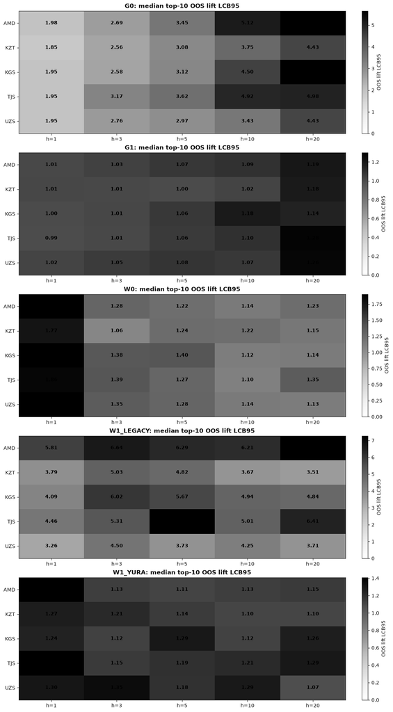

```python
plt.rcParams.update({
    'figure.facecolor': 'white', 'axes.facecolor': '#F4F4F4',
    'axes.edgecolor': '#222222', 'text.color': '#111111',
    'axes.labelcolor': '#111111', 'xtick.color': '#111111',
    'ytick.color': '#111111',
})
families = list(discovery_target_registry.family.drop_duplicates())
fig, axes = plt.subplots(len(families), 1, figsize=(11, 4 * len(families)), constrained_layout=True)
for ax, family in zip(np.atleast_1d(axes), families):
    sample = top_indicators.loc[top_indicators.target_family.eq(family)]
    matrix = sample.pivot_table(
        index='currency', columns='horizon', values='oos_lift_lcb95', aggfunc='median'
    )
    matrix = matrix.reindex(index=CURRENCIES_TO_TEST, columns=HORIZONS)
    values = matrix.to_numpy(dtype=float)
    image = ax.imshow(values, cmap='Greys', aspect='auto', vmin=0, vmax=max(1.3, np.nanpercentile(values, 95)))
    ax.set_xticks(range(len(HORIZONS)), labels=[f'h={h}' for h in HORIZONS])
    ax.set_yticks(range(len(CURRENCIES_TO_TEST)), labels=CURRENCIES_TO_TEST)
    ax.set_title(f'{family}: median top-10 OOS lift LCB95', fontweight='bold')
    for row in range(values.shape[0]):
        for column in range(values.shape[1]):
            value = values[row, column]
            ax.text(column, row, '—' if not np.isfinite(value) else f'{value:.2f}',
                    ha='center', va='center', color='black', fontweight='bold')
    fig.colorbar(image, ax=ax, label='OOS lift LCB95')
plt.show()
```

## 8. Как использовать результаты

1. Начинать с `best_indicators` и `winner_counts`, но проверять `oos_signal_count`, `oos_lift_lcb95`, BPS и стабильность fold одновременно.
2. Новый метод имеет смысл переносить в Yura, если он выигрывает не одну строку, а повторяется по нескольким валютам/горизонтам или улучшает HGB в сравнении `hgb_all − hgb_core`.
3. Высокий точечный lift при низком LCB или одном удачном fold — исследовательский шум.
4. `parameter_stability` показывает, насколько часто rolling fit выбирал одну и ту же конкретную настройку. Низкое значение не всегда плохо, но означает реальную необходимость переоптимизации.
5. Период `reserved_after` не использован. После выбора небольшой новой библиотеки её нужно один раз заморозить и проверить уже полным Yura pipeline.